# Ejercicio Tidyverse

```r
#Librerias
library(lubridate)
library(dplyr)
library(tidyr)
library(ggplot2)
```

Realizamos la lectura de los datasets y miramos su estructura

```r
ipc = read.csv('../Fuentes/ipc-mensual.csv')
dolar = read.csv('../Fuentes/dolar-diario.csv')
glimpse(ipc)
```

```
Observations: 4
Variables: 29
$ Apertura <fct> Nivel general, Estacionales, Núcleo, Regulados
$ Apr.16   <dbl> 85.5, 89.9, 85.4, 84.0
$ May.16   <dbl> 89.1, 93.7, 87.6, 91.3
$ Jun.16   <dbl> 91.9, 96.3, 90.3, 94.5
$ Jul.16   <dbl> 93.7, 99.6, 92.0, 96.3
$ Aug.16   <dbl> 93.9, 95.3, 93.5, 94.6
$ Sep.16   <dbl> 95.0, 99.2, 94.9, 93.3
$ Oct.16   <dbl> 97.2, 101.1, 96.7, 97.2
$ Nov.16   <dbl> 98.8, 101.6, 98.3, 99.1
$ Dec.16   <dbl> 100, 100, 100, 100
$ Jan.17   <dbl> 101.3, 101.6, 101.3, 101.1
$ Feb.17   <dbl> 103.8, 102.1, 103.2, 106.3
$ Mar.17   <dbl> 106.3, 105.9, 105.1, 109.9
```

[output cut: 16 more lines]

```r
glimpse(dolar)
```

```
Observations: 4,056
Variables: 2
$ Fecha                                               <fct> 04-03-02, 05-03-02, 06-03-02, 07-03-02, 08-03-02, 11-03-02,...
$ Tipo.de.Cambio.de.Referencia...en.Pesos...por.Dólar <dbl> 2.0083, 1.9917, 2.0508, 2.1375, 2.2033, 2.2525, 2.3650, 2.3...
```

Renombramos la variable del tipo de cambio por algo más sencillo

```r
dolar = dolar %>% rename(tipo_cambio = Tipo.de.Cambio.de.Referencia...en.Pesos...por.Dólar)
```

Creamos las variables fecha, año, mes y día

```r
dolar = dolar %>% mutate(date=dmy(Fecha), year=year(date), month=month(date),
                         day=day(date))
glimpse(dolar)
```

```
Observations: 4,056
Variables: 6
$ Fecha       <fct> 04-03-02, 05-03-02, 06-03-02, 07-03-02, 08-03-02, 11-03-02, 12-03-02, 13-03-02, 14-03-02, 15-03-02,...
$ tipo_cambio <dbl> 2.0083, 1.9917, 2.0508, 2.1375, 2.2033, 2.2525, 2.3650, 2.3317, 2.3650, 2.3408, 2.3175, 2.3783, 2.4...
$ date        <date> 2002-03-04, 2002-03-05, 2002-03-06, 2002-03-07, 2002-03-08, 2002-03-11, 2002-03-12, 2002-03-13, 20...
$ year        <dbl> 2002, 2002, 2002, 2002, 2002, 2002, 2002, 2002, 2002, 2002, 2002, 2002, 2002, 2002, 2002, 2002, 200...
$ month       <dbl> 3, 3, 3, 3, 3, 3, 3, 3, 3, 3, 3, 3, 3, 3, 3, 3, 3, 3, 4, 4, 4, 4, 4, 4, 4, 4, 4, 4, 4, 4, 4, 4, 4, ...
$ day         <int> 4, 5, 6, 7, 8, 11, 12, 13, 14, 15, 18, 19, 20, 21, 22, 25, 26, 27, 2, 3, 4, 5, 8, 9, 10, 11, 12, 15...
```

Seleccionamos el primer día hábil del mes para obtener la primer cotización del mes. La cotización del dólar se disponibiliza el primer día hábil del mes y no el primer día del mes.

```r
fecha_cotizacion= dolar%>% group_by(year,month) %>%
  summarise(day=min(day))
```

Realizamos el join con el dataframe del primer día hábil

```r
dolar = dolar %>% inner_join(fecha_cotizacion, by=c('year', 'month', 'day')) %>% select(-c(Fecha, day))
```

Graficamos la evolución del tipo de cambio para todo el dataset

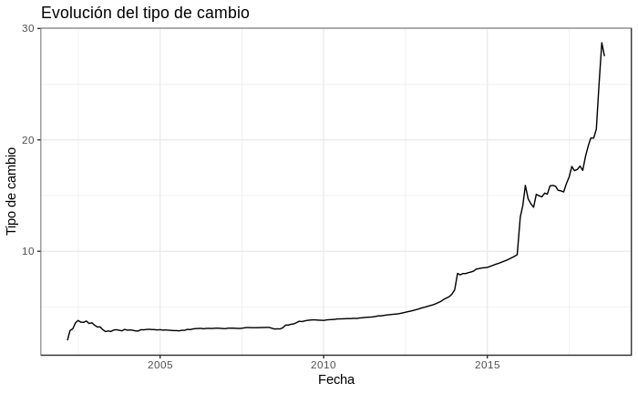

```r
ggplot(dolar, aes(x=date, y=tipo_cambio)) +
  geom_line() +
  labs(x="Fecha", y="Tipo de cambio", title="Evolución del tipo de cambio")+
  theme_bw()
```

Los datos de IPC están en un formato que hace su análisis bastante complicado. Pasamos los datos a un formato más util usando gather().

```r
ipc= ipc %>% gather(., key   = date, value = ipc, 2:29)
glimpse(ipc)
```

```
Observations: 112
Variables: 3
$ Apertura <fct> Nivel general, Estacionales, Núcleo, Regulados, Nivel general, Estacionales, Núcleo, Regulados, Nivel ...
$ date     <chr> "Apr.16", "Apr.16", "Apr.16", "Apr.16", "May.16", "May.16", "May.16", "May.16", "Jun.16", "Jun.16", "J...
$ ipc      <dbl> 85.5, 89.9, 85.4, 84.0, 89.1, 93.7, 87.6, 91.3, 91.9, 96.3, 90.3, 94.5, 93.7, 99.6, 92.0, 96.3, 93.9, ...
```

Creamos las variables fecha, año y mes

```r
ipc= ipc %>% mutate(date=ymd(parse_date_time(date, orders = 'my')),
                    year=year(date), month=month(date))
```

Graficamos la distribución del IPC a nivel general

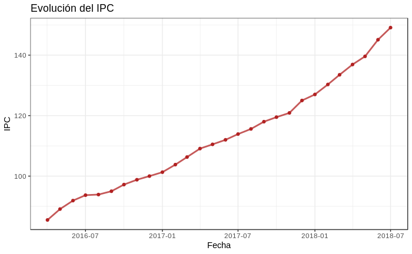

```r
ipc %>% filter(Apertura== "Nivel general") %>%
ggplot(., aes(x= date, y = ipc, group = Apertura )) +
  geom_point(color="firebrick")+
  geom_line(size= 1,alpha=0.75, color = "firebrick")+
  labs(x="Fecha", y="IPC", title="Evolución del IPC")+
  theme_bw()
```

Graficamos la distribución del IPC por grupo

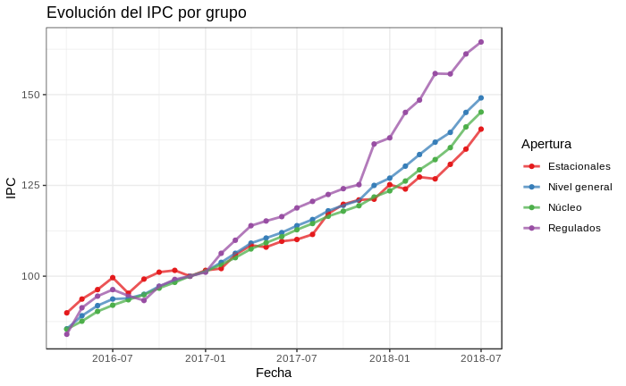

```r
ggplot(ipc, aes(x= date, y = ipc, group = Apertura, color = Apertura )) +
  geom_point()+
  geom_line(size=1,alpha=0.75)+
  labs(x="Fecha", y="IPC", title="Evolución del IPC por grupo")+
  theme_bw()+
  scale_color_brewer(palette = "Set1")
```

Procedemos a joinear ambos datasets usando como keys para joinear el año y el mes. No podemos utilizar la fecha porque van a diferir entre las bases. Utilizamos un inner join ya que solo queremos quedarnos con los meses para los cuales tenemos información del IPC y del dólar.

```r
ipc_dolar = ipc %>% inner_join(dolar, by=c('year', 'month'))
glimpse(ipc_dolar)
```

```
Observations: 112
Variables: 7
$ Apertura    <fct> Nivel general, Estacionales, Núcleo, Regulados, Nivel general, Estacionales, Núcleo, Regulados, Niv...
$ date.x      <date> 2016-04-01, 2016-04-01, 2016-04-01, 2016-04-01, 2016-05-01, 2016-05-01, 2016-05-01, 2016-05-01, 20...
$ ipc         <dbl> 85.5, 89.9, 85.4, 84.0, 89.1, 93.7, 87.6, 91.3, 91.9, 96.3, 90.3, 94.5, 93.7, 99.6, 92.0, 96.3, 93....
$ year        <dbl> 2016, 2016, 2016, 2016, 2016, 2016, 2016, 2016, 2016, 2016, 2016, 2016, 2016, 2016, 2016, 2016, 201...
$ month       <dbl> 4, 4, 4, 4, 5, 5, 5, 5, 6, 6, 6, 6, 7, 7, 7, 7, 8, 8, 8, 8, 9, 9, 9, 9, 10, 10, 10, 10, 11, 11, 11,...
$ tipo_cambio <dbl> 14.7033, 14.7033, 14.7033, 14.7033, 14.2617, 14.2617, 14.2617, 14.2617, 13.9537, 13.9537, 13.9537, ...
$ date.y      <date> 2016-04-01, 2016-04-01, 2016-04-01, 2016-04-01, 2016-05-02, 2016-05-02, 2016-05-02, 2016-05-02, 20...
```

Como existían dos columnas llamadas date, al realizar el join se le asigna por default el sufijo .x a la columna del primer dataframe y el sufijo .y al del segundo dataframe. Eliminamos una y modificamos el nombre de la restante

```r
ipc_dolar = ipc_dolar %>% rename(date=date.x) %>% select(-date.y)
```

```r
resumen=ipc_dolar %>% filter(Apertura=="Nivel general") %>%
              group_by(year) %>%
              summarise(dolar_promedio=mean(tipo_cambio),
                        desvio_dolar=sd(tipo_cambio),
                        mediana_dolar=median(tipo_cambio),
                        rango_dolar=max(tipo_cambio)-min(tipo_cambio),
                        ipc_promedio=mean(ipc),
                        desvio_ipc=sd(ipc),
                        mediana_ipc=median(ipc),
                        rango_ipc=max(ipc)-min(ipc))
resumen
```

| year | dolar_promedio | desvio_dolar | mediana_dolar | rango_dolar | ipc_promedio | desvio_ipc | mediana_ipc | rango_ipc |
| --- | --- | --- | --- | --- | --- | --- | --- | --- |
| 2016 | 14.90356 | 0.5592487 | 14.9858 | 1.9203 | 93.9000 | 4.622770 | 93.90 | 14.5 |
| 2017 | 16.48507 | 0.9046209 | 16.3697 | 2.3234 | 112.9917 | 7.199174 | 112.95 | 23.7 |
| 2018 | 21.85669 | 3.6499556 | 20.1648 | 10.1717 | 137.3571 | 7.906086 | 136.90 | 22.1 |

Con las dos fuentes de información juntas, podemos realizar gráficos conjuntos Como los rangos de las variables son muy diferentes, tenemos que utilizar un segundo eje.

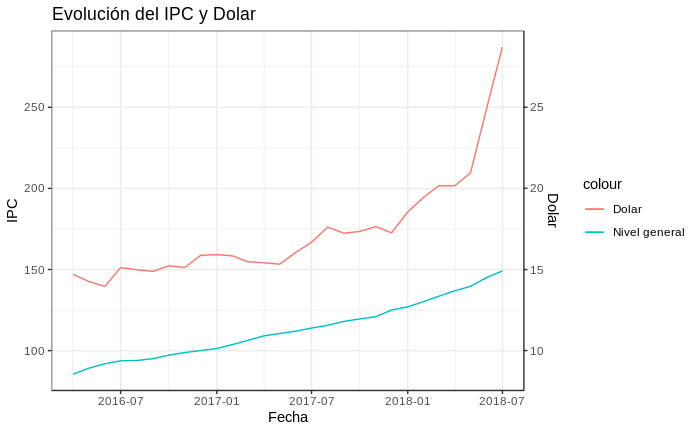

```r
ggplot()+
  geom_line(data = ipc_dolar %>% filter(Apertura=="Nivel general"),aes(x=date,y=ipc, color ="Nivel general"))+
  geom_line(data = ipc_dolar,aes(date,tipo_cambio*10, color ="Dolar"))+
  labs(x="Fecha", y="IPC", title="Evolución del IPC y Dolar")+
  theme_bw()+
  scale_y_continuous(sec.axis = sec_axis(~.*.1, name = "Dolar"))
```

También agrupando por apertura

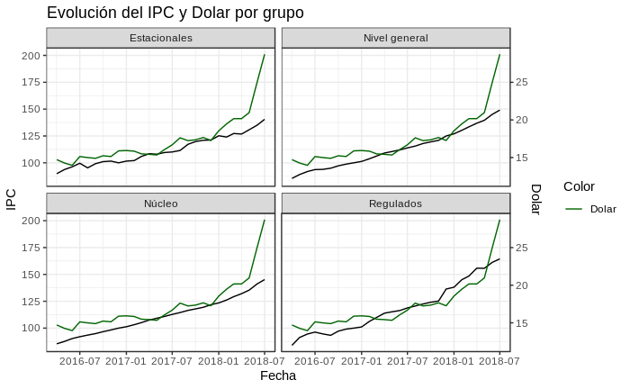

```r
ggplot()+
  geom_line(data = ipc_dolar,aes(date,ipc))+
  geom_line(data = ipc_dolar,aes(date,tipo_cambio*7, color ="Dolar"))+
  scale_y_continuous(sec.axis = sec_axis(~./7, name = "Dolar"))+
  scale_colour_manual("Color",values=c("darkgreen"))+
  theme_bw()+
  labs(x="Fecha", y="IPC", title="Evolución del IPC y Dolar por grupo")+
  facet_wrap(.~Apertura)
```